# PacBio HiFi 5mCpG Methylation QC Report

Ashkenazim Trio (HG002/HG003/HG004) — chr22 Benchmark

Author

Mateusz Sypniewski

Published

June 5, 2026

## Overview

This report validates the PacBio HiFi 5mCpG methylation calling pipeline (`nf-longread`) on chromosome 22 of the Ashkenazim Trio reference samples (HG002/HG003/HG004, NIST). Methylation calls are generated by `pb-CpG-tools aligned_bam_to_cpg_scores` using the primrose-calibrated model on phased HiFi BAMs (HiPhase). The report covers:

1. Coverage and call-rate QC
2. Beta value distribution
3. CpG genomic context annotation
4. Allele-specific methylation (ASM) landscape
5. Trio concordance

## Setup

```r
library(tidyverse)
library(data.table)
library(annotatr)
library(ggridges)
library(patchwork)
library(GenomicRanges)

theme_set(theme_bw(base_size = 12))

SAMPLES <- c("HG002", "HG003", "HG004")
CHR     <- "chr22"
COV_MIN <- 5L
```

## 1. Data Loading

```r
# --- pb-CpG-tools BED files ---
# Expected path: <PLACEHOLDER: adjust to your repo structure>
BED_DIR <- "../deployment/benchmark/trio_benchmark_results/test_run/methylation/pb-cpg"

pcpg_hap <- list.files(BED_DIR,
                       pattern = "*bed.gz$",
                       full.names = TRUE) %>%
  map(~ fread(.x, skip = 8) %>%
        mutate(
          sample = gsub(".hap[0-9]+.bed.gz$", "", basename(.x))
        ) %>%
        relocate(sample, type, .before = `#chrom`) %>%
        filter(cov >= COV_MIN,
               `#chrom` == CHR)
  ) %>%
  purrr::reduce(bind_rows) %>%
  dplyr::rename(chrom = `#chrom`)

# Combined (hap1 + hap2) per site
pcpg_combined <- pcpg_hap %>%
  group_by(sample, chrom, end) %>%
  summarise(
    beta      = sum(est_mod_count) / sum(cov),
    cov_total = sum(cov),
    .groups   = "drop"
  ) %>%
  filter(cov_total >= COV_MIN)

cat(sprintf(
  "Loaded %s CpG sites across %s samples (combined, cov >= %d)\n",
  format(nrow(pcpg_combined), big.mark = ","),
  n_distinct(pcpg_combined$sample),
  COV_MIN
))
```

```
Loaded 1,751,871 CpG sites across 3 samples (combined, cov >= 5)
```

## 2. Coverage QC

```r
# --- Mosdepth summary (PLACEHOLDER) ---
# Replace with:
# mosdepth_summary <- fread("<PLACEHOLDER: path to mosdepth summary files>")
# For now, derive coverage summary from pb-CpG-tools data

cov_summary <- pcpg_combined %>%
  group_by(sample) %>%
  summarise(
    n_cpg_sites   = n(),
    mean_cov      = mean(cov_total),
    median_cov    = median(cov_total),
    pct_ge10x     = mean(cov_total >= 10) * 100,
    pct_ge20x     = mean(cov_total >= 20) * 100,
    .groups       = "drop"
  )

knitr::kable(
  cov_summary,
  digits  = 1,
  caption = paste("Table 1. Coverage summary per sample,", CHR),
  col.names = c("Sample", "CpG sites", "Mean cov",
                "Median cov", "% ≥10×", "% ≥20×")
)
```

Table 1. Coverage summary per sample, chr22

| Sample | CpG sites | Mean cov | Median cov | % ≥10× | % ≥20× |
| --- | --- | --- | --- | --- | --- |
| HG002 | 591712 | 34.0 | 32 | 98.7 | 93.0 |
| HG003 | 590240 | 31.7 | 30 | 98.4 | 88.8 |
| HG004 | 569919 | 22.9 | 21 | 94.1 | 60.0 |

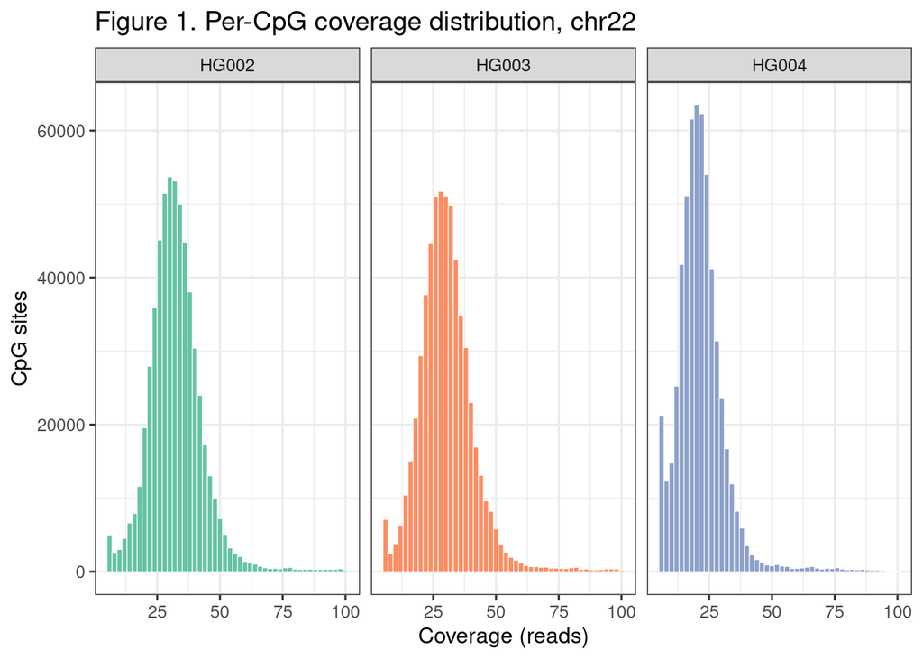

```r
pcpg_combined %>%
  filter(cov_total <= 100) %>%
  ggplot(aes(x = cov_total, fill = sample)) +
  geom_histogram(binwidth = 2, colour = "white", linewidth = 0.2) +
  facet_wrap(~ sample, ncol = 3) +
  labs(
    x     = "Coverage (reads)",
    y     = "CpG sites",
    title = paste("Figure 1. Per-CpG coverage distribution,", CHR)
  ) +
  scale_fill_brewer(palette = "Set2") +
  theme(legend.position = "none")
```

## 3. Beta Value Distribution

A bimodal distribution with peaks near 0 (hypomethylated) and 1 (hypermethylated) is expected for a healthy human methylome, reflecting the binary nature of CpG methylation at most loci.

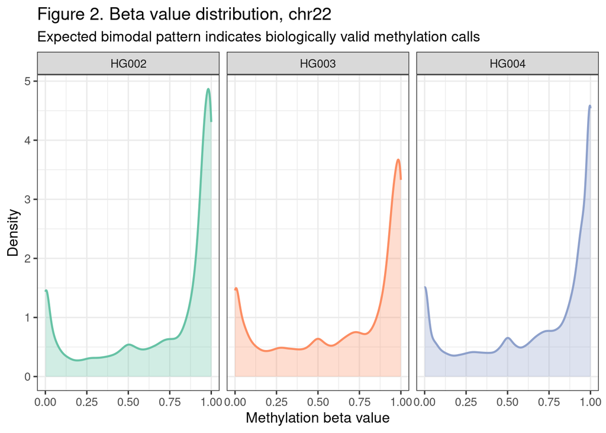

```r
pcpg_combined %>%
  ggplot(aes(x = beta, fill = sample, colour = sample)) +
  geom_density(alpha = 0.3, linewidth = 0.8) +
  facet_wrap(~ sample, ncol = 3) +
  labs(
    x     = "Methylation beta value",
    y     = "Density",
    title = paste("Figure 2. Beta value distribution,", CHR),
    subtitle = "Expected bimodal pattern indicates biologically valid methylation calls"
  ) +
  scale_fill_brewer(palette  = "Set2") +
  scale_colour_brewer(palette = "Set2") +
  theme(legend.position = "none")
```

```r
pcpg_combined %>%
  mutate(
    methylation_class = case_when(
      beta < 0.2  ~ "Hypomethylated (<20%)",
      beta > 0.8  ~ "Hypermethylated (>80%)",
      TRUE        ~ "Intermediate (20-80%)"
    )
  ) %>%
  count(sample, methylation_class) %>%
  group_by(sample) %>%
  mutate(pct = n / sum(n) * 100) %>%
  ungroup() %>%
  knitr::kable(
    digits  = 1,
    caption = "Table 2. CpG methylation class distribution per sample",
    col.names = c("Sample", "Class", "N sites", "% sites")
  )
```

Table 2. CpG methylation class distribution per sample

| Sample | Class | N sites | % sites |
| --- | --- | --- | --- |
| HG002 | Hypermethylated (>80%) | 340250 | 57.5 |
| HG002 | Hypomethylated (<20%) | 89234 | 15.1 |
| HG002 | Intermediate (20-80%) | 162228 | 27.4 |
| HG003 | Hypermethylated (>80%) | 278130 | 47.1 |
| HG003 | Hypomethylated (<20%) | 108381 | 18.4 |
| HG003 | Intermediate (20-80%) | 203729 | 34.5 |
| HG004 | Hypermethylated (>80%) | 292330 | 51.3 |
| HG004 | Hypomethylated (<20%) | 89220 | 15.7 |
| HG004 | Intermediate (20-80%) | 188369 | 33.1 |

## 4. CpG Genomic Context Annotation

Methylation patterns differ systematically by genomic context: CpG islands are typically hypomethylated (active regulatory regions), while CpG shores and open-sea CpGs are predominantly hypermethylated.

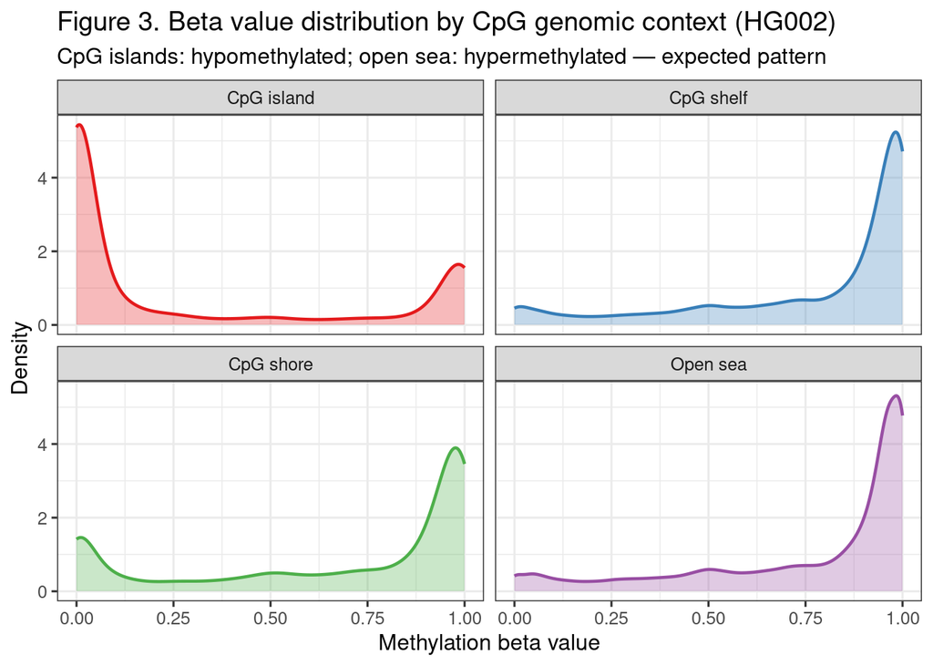

```r
# Build annotatr annotation for hg38 chr22
annots <- build_annotations(genome = "hg38",
                             annotations = c("hg38_cpg_islands",
                                             "hg38_cpg_shores",
                                             "hg38_cpg_shelves",
                                             "hg38_cpg_inter"))

# Convert pcpg_combined to GRanges for annotation
gr_cpg <- pcpg_combined %>%
  filter(sample == "HG002") %>%          # annotate once, same positions for all
  makeGRangesFromDataFrame(
    seqnames.field = "chrom",
    start.field    = "end",
    end.field      = "end",
    keep.extra.columns = TRUE
  )

annotated <- annotate_regions(
  regions     = gr_cpg,
  annotations = annots,
  ignore.strand = TRUE,
  quiet         = TRUE
) %>%
  as_tibble() %>%
  select(seqnames, start, beta, cov_total, annot.type) %>%
  mutate(
    context = case_when(
      str_detect(annot.type, "islands") ~ "CpG island",
      str_detect(annot.type, "shores")  ~ "CpG shore",
      str_detect(annot.type, "shelves") ~ "CpG shelf",
      str_detect(annot.type, "inter")   ~ "Open sea",
      TRUE                              ~ "Other"
    )
  )

annotated %>%
  ggplot(aes(x = beta, fill = context, colour = context)) +
  geom_density(alpha = 0.3, linewidth = 0.8) +
  facet_wrap(~ context, ncol = 2) +
  labs(
    x     = "Methylation beta value",
    y     = "Density",
    title = "Figure 3. Beta value distribution by CpG genomic context (HG002)",
    subtitle = "CpG islands: hypomethylated; open sea: hypermethylated — expected pattern"
  ) +
  scale_fill_brewer(palette  = "Set1") +
  scale_colour_brewer(palette = "Set1") +
  theme(legend.position = "none")
```

```r
annotated %>%
  group_by(context) %>%
  summarise(
    n_sites    = n(),
    mean_beta  = mean(beta),
    median_beta = median(beta),
    .groups    = "drop"
  ) %>%
  arrange(mean_beta) %>%
  knitr::kable(
    digits  = 3,
    caption = "Table 3. Mean methylation by genomic context (HG002, chr22)"
  )
```

Table 3. Mean methylation by genomic context (HG002, chr22)

| context | n_sites | mean_beta | median_beta |
| --- | --- | --- | --- |
| CpG island | 59887 | 0.284 | 0.032 |
| CpG shore | 61007 | 0.671 | 0.870 |
| Open sea | 429558 | 0.758 | 0.905 |
| CpG shelf | 41260 | 0.773 | 0.920 |

## 5. Allele-Specific Methylation (ASM) Landscape

HiPhase haplotype-resolved calling allows direct comparison of methylation between the two parental haplotypes at each CpG site. Sites with large |hap1 - hap2| differences are candidate ASM loci.

```r
asm <- pcpg_hap %>%
  select(sample, chrom, end, type, beta = mod_score, cov) %>%
  mutate(beta = beta / 100) %>%       # mod_score is 0-100, convert to 0-1
  pivot_wider(
    names_from  = type,
    values_from = c(beta, cov),
    names_sep   = "_"
  ) %>%
  filter(!is.na(beta_hap1), !is.na(beta_hap2)) %>%
  mutate(asm_delta = abs(beta_hap1 - beta_hap2))
```

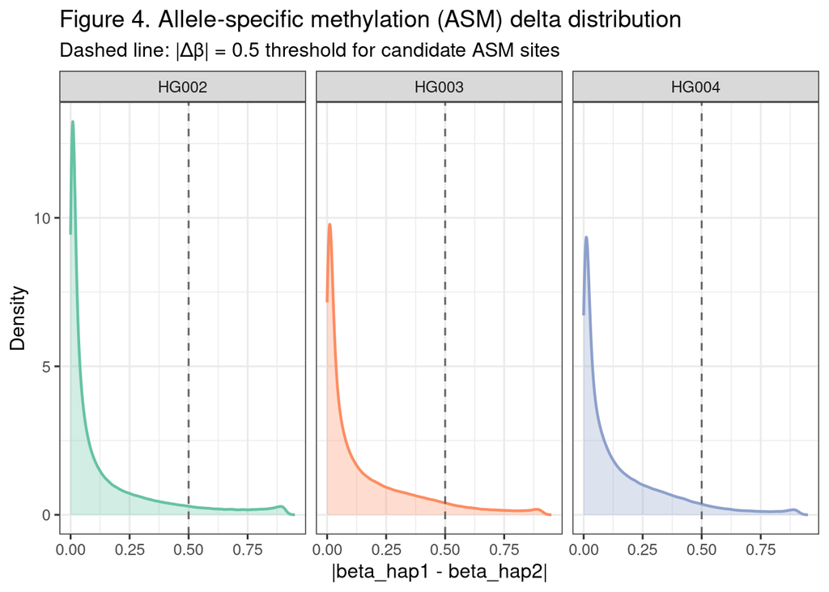

```r
asm %>%
  ggplot(aes(x = asm_delta, fill = sample, colour = sample)) +
  geom_density(alpha = 0.3, linewidth = 0.8) +
  facet_wrap(~ sample, ncol = 3) +
  geom_vline(xintercept = 0.5, linetype = "dashed", colour = "grey40") +
  labs(
    x        = "|beta_hap1 - beta_hap2|",
    y        = "Density",
    title    = "Figure 4. Allele-specific methylation (ASM) delta distribution",
    subtitle = "Dashed line: |Δβ| = 0.5 threshold for candidate ASM sites"
  ) +
  scale_fill_brewer(palette  = "Set2") +
  scale_colour_brewer(palette = "Set2") +
  theme(legend.position = "none")
```

```r
asm %>%
  group_by(sample) %>%
  summarise(
    n_sites      = n(),
    pct_asm_05   = mean(asm_delta >= 0.5) * 100,
    pct_asm_03   = mean(asm_delta >= 0.3) * 100,
    mean_delta   = mean(asm_delta),
    .groups      = "drop"
  ) %>%
  knitr::kable(
    digits  = 2,
    caption = "Table 4. ASM site counts per sample (chr22)",
    col.names = c("Sample", "Total sites", "% |Δβ|≥0.5", "% |Δβ|≥0.3", "Mean |Δβ|")
  )
```

Table 4. ASM site counts per sample (chr22)

| Sample | Total sites | % \|Δβ\|≥0.5 | % \|Δβ\|≥0.3 | Mean \|Δβ\| |
| --- | --- | --- | --- | --- |
| HG002 | 575834 | 8.75 | 17.16 | 0.15 |
| HG003 | 572275 | 8.46 | 20.39 | 0.16 |
| HG004 | 511690 | 7.07 | 19.05 | 0.16 |

```r
# Top ASM candidate sites
asm %>%
  filter(asm_delta >= 0.5, sample == "HG002") %>%
  arrange(desc(asm_delta)) %>%
  select(chrom, end, beta_hap1, beta_hap2, asm_delta, cov_hap1, cov_hap2) %>%
  head(20) %>%
  knitr::kable(
    digits  = 3,
    caption = "Table 5. Top 20 candidate ASM loci on chr22 (HG002, |Δβ| ≥ 0.5)"
  )
```

Table 5. Top 20 candidate ASM loci on chr22 (HG002, |Δβ| ≥ 0.5)

| chrom | end | beta_hap1 | beta_hap2 | asm_delta | cov_hap1 | cov_hap2 |
| --- | --- | --- | --- | --- | --- | --- |
| chr22 | 43834870 | 0.024 | 0.974 | 0.950 | 10 | 13 |
| chr22 | 21688797 | 0.028 | 0.975 | 0.947 | 17 | 8 |
| chr22 | 21688799 | 0.028 | 0.974 | 0.946 | 17 | 8 |
| chr22 | 40940720 | 0.967 | 0.021 | 0.946 | 6 | 7 |
| chr22 | 23566977 | 0.030 | 0.976 | 0.946 | 8 | 7 |
| chr22 | 43834900 | 0.025 | 0.970 | 0.945 | 11 | 13 |
| chr22 | 47149262 | 0.025 | 0.970 | 0.945 | 12 | 17 |
| chr22 | 30921990 | 0.023 | 0.967 | 0.944 | 20 | 14 |
| chr22 | 30922347 | 0.028 | 0.972 | 0.944 | 21 | 14 |
| chr22 | 41682094 | 0.032 | 0.976 | 0.944 | 13 | 15 |
| chr22 | 30922253 | 0.029 | 0.971 | 0.942 | 21 | 14 |
| chr22 | 41682089 | 0.028 | 0.970 | 0.942 | 13 | 15 |
| chr22 | 48580655 | 0.974 | 0.033 | 0.941 | 15 | 22 |
| chr22 | 41682234 | 0.031 | 0.972 | 0.941 | 13 | 15 |
| chr22 | 41682236 | 0.029 | 0.970 | 0.941 | 13 | 15 |
| chr22 | 41681822 | 0.034 | 0.974 | 0.940 | 12 | 15 |
| chr22 | 47149280 | 0.024 | 0.964 | 0.940 | 12 | 17 |
| chr22 | 30922343 | 0.030 | 0.970 | 0.940 | 21 | 14 |
| chr22 | 43834842 | 0.028 | 0.968 | 0.940 | 6 | 11 |
| chr22 | 48580657 | 0.970 | 0.030 | 0.940 | 15 | 22 |

## 6. Trio Concordance

Methylation beta values should be highly concordant across the Ashkenazim Trio at constitutively methylated and unmethylated loci, confirming pipeline stability across samples sequenced in independent runs.

```r
# Wide format: one column per sample
trio_wide <- pcpg_combined %>%
  select(chrom, end, sample, beta) %>%
  pivot_wider(names_from = sample, values_from = beta) %>%
  drop_na()

cat(sprintf("Shared CpG sites across all three samples: %s\n",
            format(nrow(trio_wide), big.mark = ",")))
```

```
Shared CpG sites across all three samples: 543,311
```

```r
# Pairwise correlations
pairs <- list(
  c("HG002", "HG003"),
  c("HG002", "HG004"),
  c("HG003", "HG004")
)

cor_table <- pairs %>%
  map_dfr(~ tibble(
    pair    = paste(.x, collapse = " vs. "),
    pearson = cor(trio_wide[[.x[1]]], trio_wide[[.x[2]]],
                  use = "complete.obs", method = "pearson"),
    spearman = cor(trio_wide[[.x[1]]], trio_wide[[.x[2]]],
                   use = "complete.obs", method = "spearman")
  ))

knitr::kable(
  cor_table,
  digits  = 4,
  caption = "Table 6. Pairwise methylation concordance across Ashkenazim Trio (chr22)"
)
```

Table 6. Pairwise methylation concordance across Ashkenazim Trio (chr22)

| pair | pearson | spearman |
| --- | --- | --- |
| HG002 vs. HG003 | 0.8084 | 0.7681 |
| HG002 vs. HG004 | 0.8250 | 0.7539 |
| HG003 vs. HG004 | 0.8253 | 0.7744 |

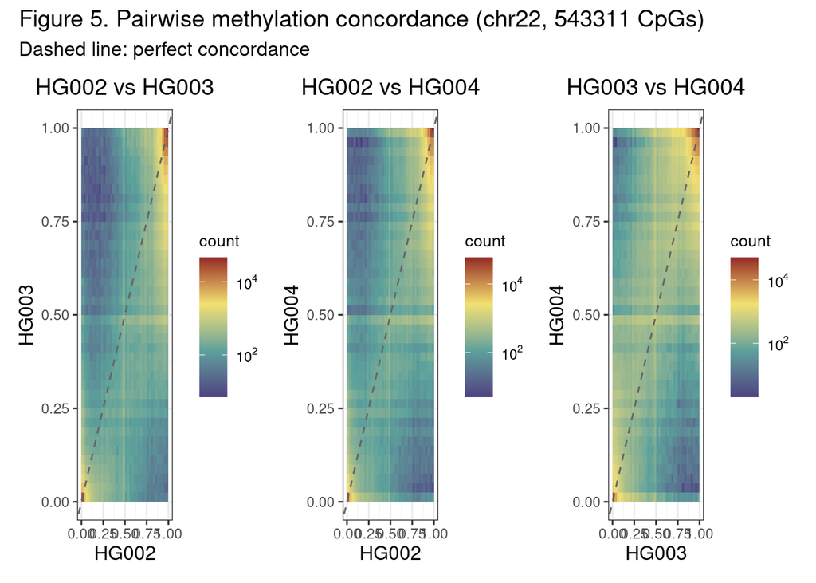

```r
p_02_03 <- trio_wide %>%
  ggplot(aes(x = HG002, y = HG003)) +
  geom_bin2d(bins = 40) +
  scale_fill_gradientn(
    trans = "log10",
    colors = c("#4e4382", "#5ca29c", "#f2e172", "#942727"),
    breaks = c(1e0, 1e2, 1e4, 1e6),
    labels = expression(10^0, 10^2, 10^4, 10^6)
  ) +
  labs(
    title = "HG002 vs HG003",
    x = "HG002",
    y = "HG003",
    fill = "count"
  ) +
  scale_x_continuous(limits = c(0, 1), breaks = seq(0, 1, 0.25)) +
  scale_y_continuous(limits = c(0, 1), breaks = seq(0, 1, 0.25)) +
  theme_bw() +
  theme(
    plot.title = element_text(hjust = 0.5, size = 14, face = "plain"),
    panel.grid.major = element_line(color = "grey92"),
    panel.grid.minor = element_line(color = "grey96"),
    axis.title = element_text(size = 12),
    legend.title = element_text(size = 10)
  )  +
  geom_abline(slope = 1, intercept = 0,
              linetype = "dashed", colour = "grey40")



p_02_04 <- trio_wide %>%
  ggplot(aes(x = HG002, y = HG004)) +
  geom_bin2d(bins = 40) +
  scale_fill_gradientn(
    trans = "log10",
    colors = c("#4e4382", "#5ca29c", "#f2e172", "#942727"),
    breaks = c(1e0, 1e2, 1e4, 1e6),
    labels = expression(10^0, 10^2, 10^4, 10^6)
  ) +
  labs(
    title = "HG002 vs HG004",
    x = "HG002",
    y = "HG004",
    fill = "count"
  ) +
  scale_x_continuous(limits = c(0, 1), breaks = seq(0, 1, 0.25)) +
  scale_y_continuous(limits = c(0, 1), breaks = seq(0, 1, 0.25)) +
  theme_bw() +
  theme(
    plot.title = element_text(hjust = 0.5, size = 14, face = "plain"),
    panel.grid.major = element_line(color = "grey92"),
    panel.grid.minor = element_line(color = "grey96"),
    axis.title = element_text(size = 12),
    legend.title = element_text(size = 10)
  )  +
  geom_abline(slope = 1, intercept = 0,
              linetype = "dashed", colour = "grey40")

p_03_04 <- trio_wide %>%
  ggplot(aes(x = HG003, y = HG004)) +
  geom_bin2d(bins = 40) +
  scale_fill_gradientn(
    trans = "log10",
    colors = c("#4e4382", "#5ca29c", "#f2e172", "#942727"),
    breaks = c(1e0, 1e2, 1e4, 1e6),
    labels = expression(10^0, 10^2, 10^4, 10^6)
  ) +
  labs(
    title = "HG003 vs HG004",
    x = "HG003",
    y = "HG004",
    fill = "count"
  ) +
  scale_x_continuous(limits = c(0, 1), breaks = seq(0, 1, 0.25)) +
  scale_y_continuous(limits = c(0, 1), breaks = seq(0, 1, 0.25)) +
  theme_bw() +
  theme(
    plot.title = element_text(hjust = 0.5, size = 14, face = "plain"),
    panel.grid.major = element_line(color = "grey92"),
    panel.grid.minor = element_line(color = "grey96"),
    axis.title = element_text(size = 12),
    legend.title = element_text(size = 10)
  )  +
  geom_abline(slope = 1, intercept = 0,
              linetype = "dashed", colour = "grey40")

(p_02_03 | p_02_04 | p_03_04) +
  plot_annotation(
    title    = "Figure 5. Pairwise methylation concordance (chr22, 543311 CpGs)",
    subtitle = "Dashed line: perfect concordance"
  )
```